# 02 - Naključni sprehodi

Matematično-fizikalni praktikum, oktober 2023  
Luka Skeledžija, 28201079

## Uvod

Naključni sprehodi so vrsta gibanja, pri katerem v velikem številu korakov napredujemo iz izhodišča v neko končno lego, tako da se parametri vsakega naslednjega koraka sproti naključno določajo. Običajni zgled je Brownovo gibanje (difuzija) drobnih delcev barvila po mirujoči homogeni tekočini, kjer je spočetka barvilo zbrano v izhodišču. "Težišče" barvila $\langle x(t)\rangle$ v povprečju ostane v izhodišču, razen če v tekočini vzpostavimo kako anizotropijo (na primer v dveh razsežnostih z vsiljeno rotacijo). "Razmazanost" po dolgem času je sorazmerna s časom, \begin{equation*} \sigma^2(t) \equiv \langle x^2(t)\rangle - \langle x(t)\rangle^2 = 2 D t \>. \end{equation*} Sorazmernostni koeficient je običajna difuzijska konstanta, priča smo normalni difuziji. Ta rezultat izhaja iz centralnega limitnega teorema (CLT), ki izraža, da je rezultantna porazdelitev končnih leg pri difuziji porazdeljena normalno (Gauss), če so le povprečni časi med koraki in povprečni kvadrati dolžin korakov končni.

Zanimiveje je opazovati naključne sprehode, pri katerih dovolimo nadpovprečno dolge korake. Verjetnostno gostoto porazdelitve po dolžinah posameznih korakov parametrizirajmo v potenčni obliki $$ \begin{equation} p(l) \propto l^{-\mu} \>, \end{equation} $$ kjer naj bo $1 < \mu < 3$. Tedaj postane drugi moment porazdelitve $$ \begin{equation*} \langle l^2\rangle = \int l^2 p(l) \; dl \end{equation*} $$ neskončen. Govorimo o anomalni difuziji, prisotni pri celi dru\v zini kinematičnih distribucij dolžin poti z "debelimi repi". Ustrezno sliko naključnega gibanja, povezanega s temi dolgimi koraki, lahko interpretiramo na dva načina:

- Levyjev pobeg oz. polet (flight), implicira, da vsak korak iz porazdelitve (1) traja enako dolgo, medtem ko se hitrost gibanja med koraki (divje) spreminja.
- Levyjev sprehod (walk), ki interpretira korak iz porazdelitve (1) kot gibanje s konstantno hitrostjo in tako koraki trajajo različno dolgo časa (dolžina koraka je sorazmerna s časom).

Slednja intepretacija bolj ustreza fizikalni sliki naključnega gibanja delca skozi snov, medtem ko se prva interpretacija uporablja v drugačnih aplikacijah.

Pri anomalni difuziji razmazanost (varianca) velike množice končnih leg naključnih Levyjevih sprehodov (walks) narašča z drugačno potenco časa. Velja $\sigma^2(t) \sim t^\gamma$, kjer je $$ \begin{align*} 1 < \mu < 2 \>, &\qquad \gamma = 2 \> &\qquad& \text{(balistični režim)}\>, \\ 2 < \mu < 3 \>, &\qquad \gamma = 4 - \mu &\qquad& \text{(super-difuzivni režim)}\>, \\ \mu > 3 \>, &\qquad \gamma = 1 &\qquad& \text{(normalna difuzija)} \>. \end{align*} $$

Slika je nekoliko drugačna pri opazovanju naključnih Levyjevih poletov (flights). Spet vzamemo zvezo $\sigma^2(t) \sim t^\gamma$ in dobimo odvisnosti $$ \begin{align*} 1 < \mu < 3 \>, &\qquad \gamma = \frac{2}{\mu-1} \> &\qquad& \text{(super-difuzivni režim)}\>, \\ \mu > 3 \>, &\qquad \gamma = 1 &\qquad& \text{(normalna difuzija)} \>. \end{align*} $$

Pri analizi difuzije bomo potrebovali kako robustno mero za množico vrednosti $X_i$, na primer MAD, "median absolute deviation". $$ \begin{equation*} \mathrm{MAD} \equiv \mathrm{median}_i\left( | X_i - \mathrm{median}_j X_j | \right) \>. \end{equation*} $$ Z njo merimo povprečje absolutne vrednosti deviacije na način, ki je zelo malo občutljiv na oddaljene vrednosti v repih porazdelitve, saj te vrednosti na račun mediane bistveno manj vplivajo kot na račun običajne povprečne vrednosti.

## Naloga

> Napravi računalniško simulacijo dvorazsežne naključne hoje za polete in sprehode. Začni vedno v izhodišču ($x=y=0$), nato pa določi naslednjo lego tako, da naključno izbereš smer koraka in statistično neodvisno od te izbire še njegovo dolžino, torej $$ x \leftarrow x + l \cos\phi, $$ $$ y \leftarrow y + l \sin\phi, $$ kjer je $\phi$ enakomerno naključno porazdeljen po intervalu $[0,2\pi]$, dolžina koraka $l$ pa naj bo porazdeljena v skladu s potenčno obliko (1). Dolžine $l_i$ je v tem primeru potrebno generirati po verjetnostni porazdelitvi w(l)$\sim$ p(l) (1). Za izračun algoritma je osnova naslednja formula: $$ \begin{equation*} \int\limits_{a}^{l} w(t)\, dt = \rho \cdot \int\limits_{a}^{b} w(t)\, dt, \end{equation*} $$ ki jo je potrebno rešiti in iz nje izraziti spremenljivko $l$. Tu je $\rho$ (psevdo-)naključno število na intervalu $[0,1]$ ter je $[a,b]$ relevantni interval vzorčenja.

## Pristop k problemu

Računalniške simulacije naključnih sprehodov se bomo lotili po korakih. Potrebujemo:

1. Naključni generator števil, ki deluje v skladu z ustrezno verjetnostno porazdelitvijo. Ustrezno porazdelitev moramo še poiskati.
2. Generator slik / animacij naključnih sprehodov *in* poletov.
3. Izračunati $\sigma^2$, določiti faktor $\gamma$ in klasificirati difuzijske režime ($\sigma^2(t) \sim t^\gamma$). Da to lahko naredimo, moramo poiskati tudi ustrezen postopek za izračun variance, saj v našem režimu velja $ \left\langle l^2 \right\rangle \to \infty$.

## Generator naključnih števil

Opazujemo naključne sprehode, pri katerih dovolimo nadpovprečno dolge korake (dolgi koraki so sedaj precej bolj pogosto kot pri npr. normalni porazdelitvi). Verjetnostno gostoto porazdelitve parametriziramo v potenčni obliki

$$ \begin{equation*} p(l) \propto l^{-\mu}. \end{equation*} $$

Ustrezne distribucije iščemo znotraj družine [porazdelitev z "debelimi repi"](https://en.wikipedia.org/wiki/Fat-tailed_distribution), bolj konkretno znotraj t.i. ["power-law" porazdelitev](https://en.wikipedia.org/wiki/Power_law#Power-law_probability_distributions). Iskanim zahtevam ustreza npr. [Paretova porazrelitev](https://en.wikipedia.org/wiki/Pareto_distribution), ki ima formalno gledano precej preprosto obliko

$$ p(x) = \frac{a}{x^{a+1}}, $$

kjer je $x \geq 1$ in $a > 0$. V dokumentaciji Pythonskega paketa `numpy` najdemo že implementiran generator naključnih števil `numpy.random.pareto(a, n)`, ki za dano potenco $a$ vrne $n$ naključnih števil po II. Paretovi oz. Lomaxovi porazdelitvi (za 1 v levo zamaknjena klasična Paretova porazdelitev).

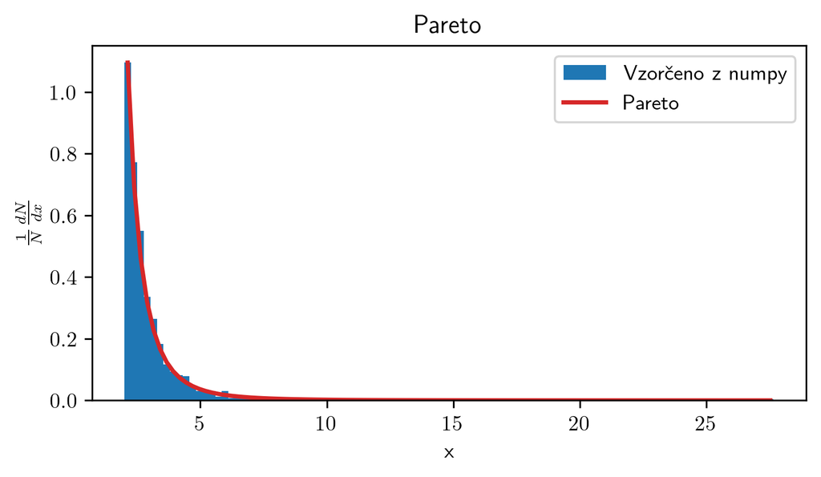

## Slike sprehodov in poletov

Slike poletov oz. sprehodov bomo generirali s Paretovo porazdelitvijo s štirimi različnimi parametri $\mu = a + 1$. Čas poleta bo sorazmeren s številom korakov, čas sprehoda pa z vsoto dolžine korakov. Ker je med sprehodi in poleti različna le časovna odvisnost pozicije, bo sled poti v $xy$ ravnini enaka za polete in sprehode. V tabeli označimo vrednosti $\mu$, $\text{seed}$, $n$, $t_f$ (čas trajanja poleta).

| mu | seed | n | t_f |
| --- | --- | --- | --- |
| 3.75 | 13401 | [10, 100, 1000, 10000] | 10000 |
| 3.25 | 14368 | [10, 100, 1000, 10000] | 10000 |
| 2.75 | 15335 | [10, 100, 1000, 10000] | 10000 |
| 2.25 | 16302 | [10, 100, 1000, 10000] | 10000 |

**Tabela 1**: Konfiguracije za 4 različne sprehode oz. polete. Čas vsakega poleta oz. sprehoda določimo za najdaljšo simulacijo ($n = 10^4$).

Sedaj narišemo naključne sprehode in vsakega v interpretaciji Levyjevih poletov tudi animiramo.

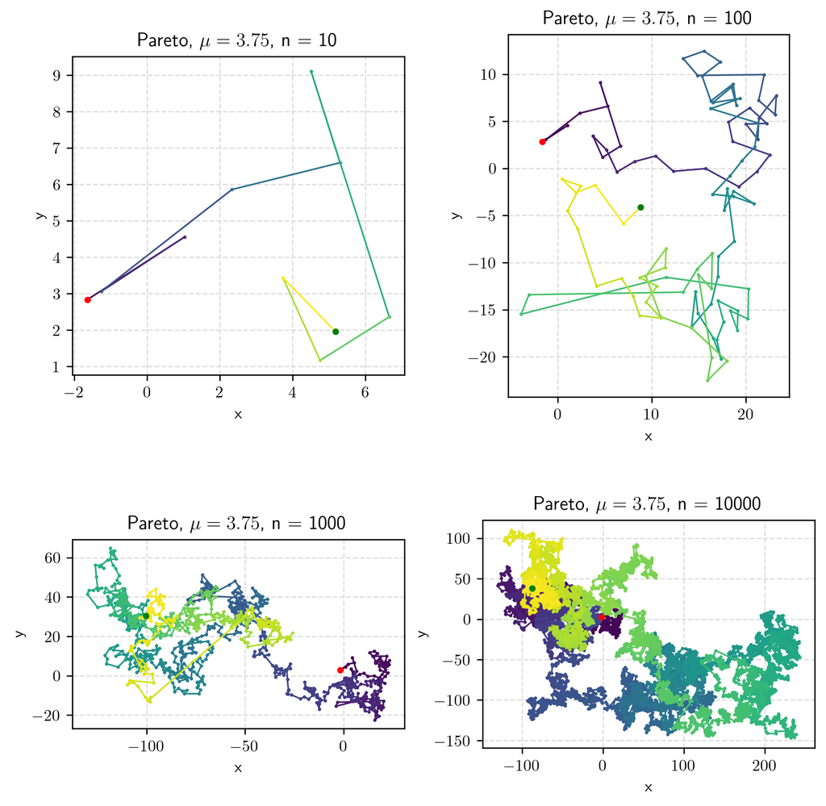

[video not shown]

**Animacija 1:** Levyjev polet za $\mu = 3.75$, Paretova porazdelitev

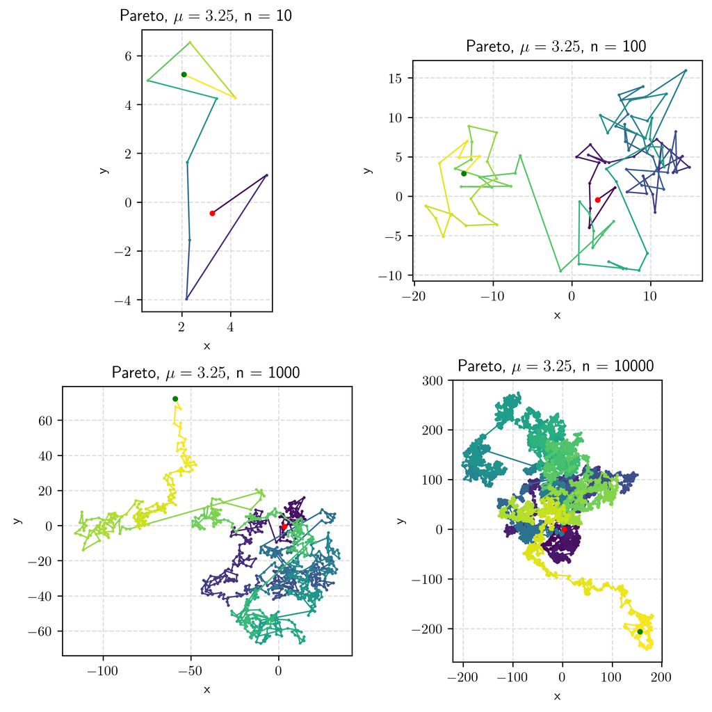

[video not shown]

**Animacija 2:** Levyjev polet za $\mu = 3.25$, Paretova porazdelitev

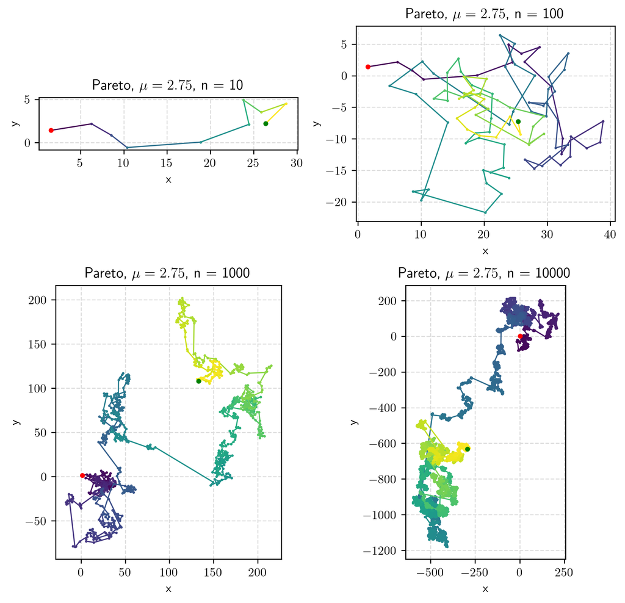

[video not shown]

**Animacija 3:** Levyjev polet za $\mu = 2.75$, Paretova porazdelitev

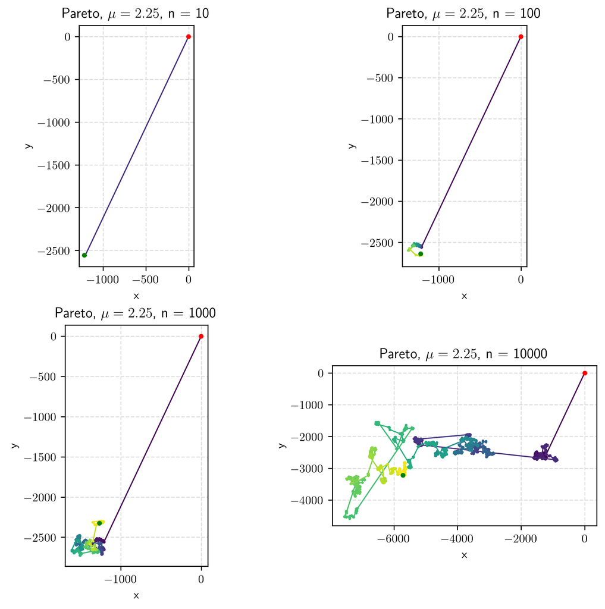

[video not shown]

**Animacija 4:** Levyjev polet za $\mu = 2.25$, Paretova porazdelitev

## Klasifikacija difuzijskih režimov

Za vsak $\mu$ in $n = 10^4$ iz tabele 1 ustvarimo dodatnih 300 simulacij z različnimi vrednostmi $\text{seed}$, da dobimo (približno) statistično reprezentativen nabor podatkov. V nadaljni analizi bomo s pomočjo teh simulacij namreč določili še režim difuzije.

Ker imamo sedaj na voljo 300 simulacij za vsak $\mu$, lahko animiramo difuzijo v nekem (ustreznem) fizikalnem sistemu s 300 delci, ki se gibljejo po dani porazdelitvi.

[video not shown]

**Animacija 5**: Simulacija 2D porazdelitve delcev (Levyjevivi poleti) v odvisnosti od časa za $\mu = 3.75$

V nadaljni analizi nas bo zanimala odvisnost "razmazanosti" od časa. Namesto klasične variance bomo uporabili robustno mero "median absolute deviation" oz. $\mathrm{MAD}$. Izračunamo jo za vse simulacije za vsak $t$ pri poletih in sprehodih. Tedaj na logaritemski graf prilagajamo premico in s tem določimo odvisnost spreminjanja $\mathrm{MAD}$ (oz. "razmazanosti") s časom. Trdimo, da je $\mathrm{MAD}^2(t) \sim \sigma^2(t) \sim t^\gamma$ in tako dobimo relativno dobro oceno za kvantifikator režima difuzije $\gamma$.

### Poleti

Po opisanem postopku sedaj izračunamo vrednosti za polete.

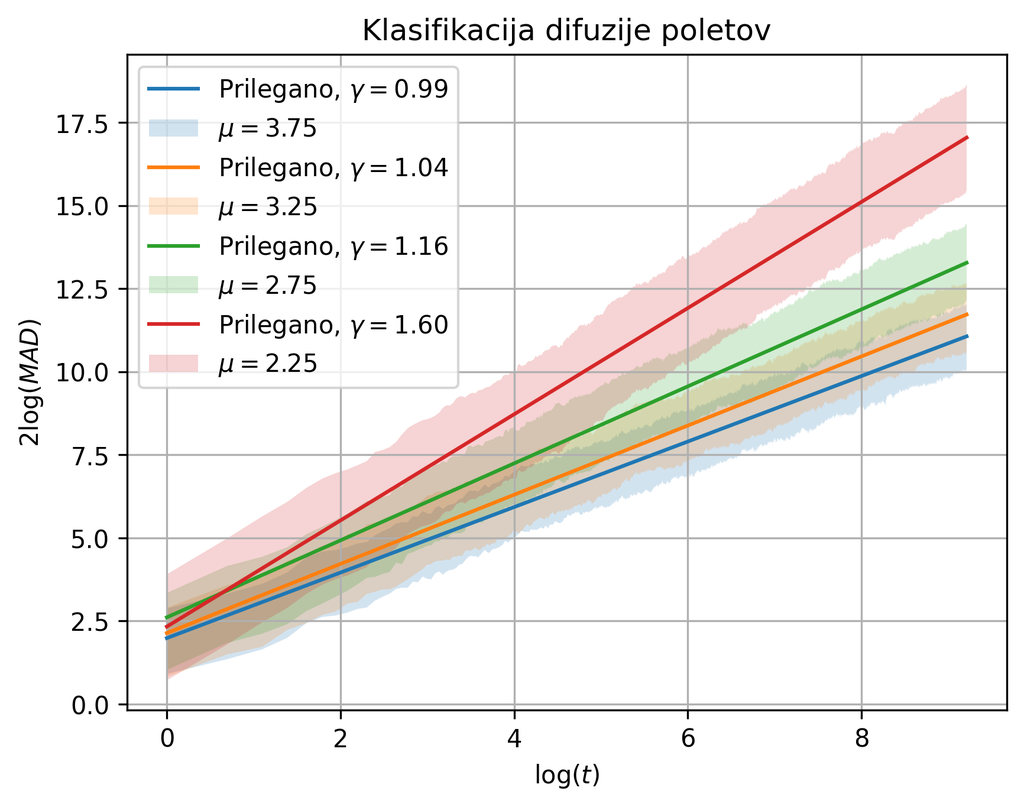

| $\mu$ | $\gamma_c$ | $\gamma_r$ | $\|\gamma_r - \gamma_c\|$ | $\pm \; \Delta \gamma_c$ | $\sigma_{\text{MAD}}$ | Tip |
| --- | --- | --- | --- | --- | --- | --- |
| 3.75 | 0.99 | 1.00 | 0.01 | 0.22 | 0.98 | normalna dif. |
| 3.25 | 1.04 | 1.00 | 0.04 | 0.25 | 1.04 | normalna dif. |
| 2.75 | 1.16 | 1.14 | 0.02 | 0.30 | 1.16 | super-difuzivni nač. |
| 2.25 | 1.60 | 1.60 | 0.00 | 0.35 | 1.59 | super-difuzivni nač. |

**Tabela 2**: Primerjava izračunanih in teoretičnih vrednostmi za polete.

### Sprehodi

Gibanje, ki ga opazujemo, lahko interpretiramo tudi s sprehodi. Prej simulirano gibanje delcev, kjer se je spreminjala hitrost in je vsak korak trajal enako dolgo, moramo za opazovanje sprehodov transformirati (interpolirati). V sliki sprehodov je sedaj konstantna hitrost, čas sprehoda pa je sorazmeren s prehojeno potjo in ne več s številom korakov. Uporabimo naslednjo formulo, kjer naredimo napako oz. približek in razdaljo koraka zaokrožimo na najbližje celo število. Velja

$$ t_{\text{walk}} = \sum_n \; \frac{\text{round}[ \, d(x_n - x_{n-1}) \,]}{\overline{v}}, \quad \overline{v} = 1. $$

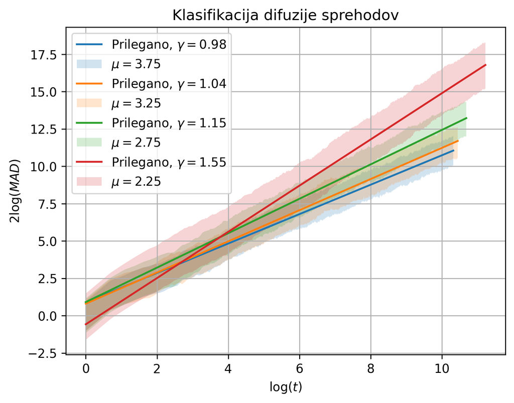

| $\mu$ | $\gamma_c$ | $\gamma_r$ | $\|\gamma_r - \gamma_c\|$ | $\pm \; \Delta \gamma_c$ | $\sigma_{\text{MAD}}$ | Tip |
| --- | --- | --- | --- | --- | --- | --- |
| 3.75 | 0.98 | 1.00 | 0.02 | 0.28 | 0.99 | normalna dif. |
| 3.25 | 1.04 | 1.00 | 0.04 | 0.26 | 1.04 | normalna dif. |
| 2.75 | 1.15 | 1.25 | 0.10 | 0.30 | 1.15 | super-difuzivni nač. |
| 2.25 | 1.55 | 1.75 | 0.20 | 0.22 | 1.55 | super-difuzivni nač. |

**Tabela 3**: Primerjava izračunanih in teoretičnih vrednostmi za sprehode.

## Dodatek: "Sticking time"

Naključno spreminjamo še čas, ko delec pred naslednjim korakom miruje (s tako dodatno prostostno stopnjo poskušamo modelirati tako imenovani "sticking time" ali "trapping time" pri anomalni difuziji elektronov v amorfnih snoveh). Ustrezna verjetnostna gostota ima potenčno odvisnost $$ p(t) \propto t^{-\nu} \>, $$ kjer $1 < \nu < 2$.

V našem primeru se odločimo za $\nu = 1.9$, saj se čas sprehoda z dodajanjem "sticking time" konkretno podaljša (pri izbranem $\nu$ pa je ta efekt najmanjši in posledično dobimo hitrejši izračun).

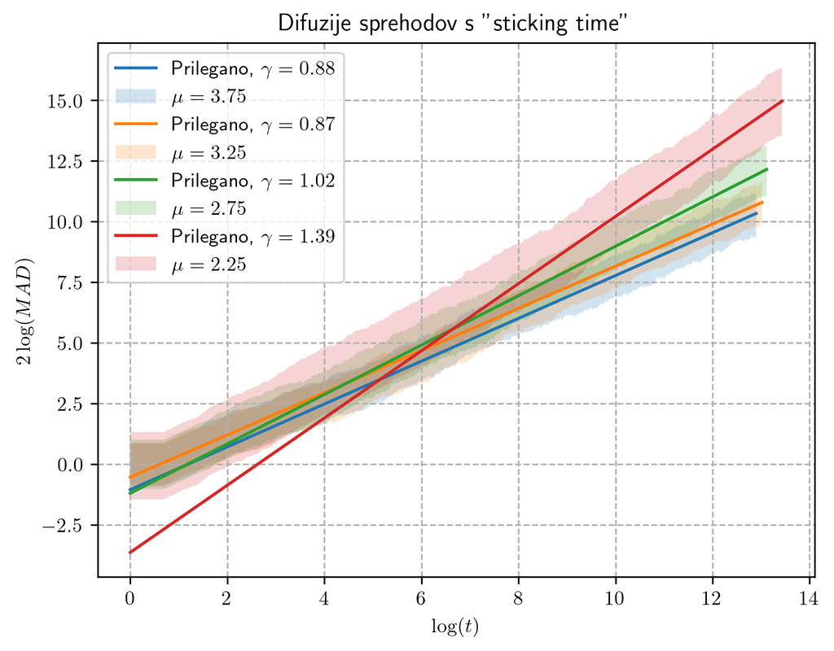

[output not shown]

**Tabela 4**: Primerjava izračunanih in teoretičnih vrednostmi za sprehode s "sticking time".

[figure not shown]

## Zaključek

V okviru tega poročila smo poiskali ustrezno porazdelitev $p(l) \propto l^{-\mu}$ in po njej generirali naključne korake za različne vrednosti števila $\mu$. Naključno korakanje smo narisali in animirali. V nadaljevanju smo število simulacij za vsak $\mu$ še povečali (n=300) in tako simulirali časovni razvoj difuzije *takšnega* fizikalnega sistema s 300 delci. Dogajanje smo animirali v interpretaciji Levyjevih poletov za $\mu = 3.75$. Nato pa smo za vsak $\mu$ na podlagi dodatnih simulacij določili kvantifikator faktor $\gamma$ za Levyjeve polete in sprehode. Tipe difuzije smo klasicifirali. Ker v našem primeru velja $\sigma^2 \to \infty$, smo za oceno faktorja $\gamma$ uporabili robustno mero množice - $\mathrm{MAD}$. Dodatno smo analizirali še sprehode z dodanim t.i. "sticking time" in ugotovili, da ima to nezanemarljiv vpliv na faktor $\gamma$.

Luka Skeledžija, [Github source 🔗](https://github.com/lukaske/mafijski-praktikum/tree/main/MFPR/02_randwalk), 2023